# Math 578B -- Fall 2015 -- Homework #4

Peter Ralph

due 22 September

**1.** Suppose we have a 10 cm$^2$ plate of bacteria, at the (low) density $10^5$ cells/cm^2. We provide the bacteria with a food source that they cannot normally utilize, but that each bacterial cell has a small probability $\mu$ of carrying a mutation that allows that cell to utilize the food source.

1. What is the probability of there being $n$ bacteria carrying the mutation on the plate, as a function of $\mu$? (Regardless of if they've grown or not.)

   **Solution:**

   This is well-modeled by a Poisson process, so if we let $\nu=\mu\times10^{6}$, this is $e^{-\nu} \nu^n/n!$.
2. Suppose that each cell that does carry the mutation waits a random number of minutes (with an Exponential distribution of mean 20) and then begins growing, eventually forming clusters that we can see, and count. A cluster that has been growing for $t$ minutes has radius $1.05^t \times 10^{-3}$cm, and we can only detect clusters with radius at least 0.01cm. Suppose we counted 17 clusters of radius at least 0.01cm after 1 hour: use this datum to give an estimate of $\mu$.

   **Solution:**

   To have grown to 0.01cm in 1 hours = 60 minutes, they must have been growing for $\log(10)/\log(1.05)=47.2$ minutes, and so have started growing within the first 60-47.2=12.8 minutes. The chance of this is $1-\exp(-12.8/20)=0.473$. By Poisson coloring, the number of colonies that have done so is Poisson with intensity $\nu \times 0.473$, and so the maximum likelihood estimator for $\nu$ is $17/0.473=35.95$, and the estimator for $\mu$ is $3.595 \times 10^{-5}$.
3. Now suppose that each cell carrying the mutation fails to begin growing, and instead dies, with probability $p$. Explain why we cannot estimate both $\mu$ and $p$ separately from these data.

   **Solution:**

   Concretely, if $\Lambda$ is the configuration of cells that have begun growing, then the distribution of $\Lambda$ depends only on $\mu (1-p)$. Then suppose that $\mu (1-p) = \mu' (1-p')$, and we have observations of cells with parameters either $(\mu,p)$ or $(\mu',p')$. Since any set of measurements about the data have the same likelihood under both sets of parameters, the result of any procedure that guesses which set of parameters was the true set is independent (in the probabilistic sense) of the truth.

**2.** Suppose that a class of deleterious mutations enters a large population of size $N$ at rate $\mu$ per birth: each new individual born has probability $\mu$ of being born with a new deleterious mutation not carried by her parents. Suppose that each such new mutation is of a new type, that an individual carrying $n$ mutations leaves behind on average $(1-s)^n$ copies of each of her genes, and that $\mu$ is small, so we can neglect the chance of someone being born with two new ones. In class, we showed that the number and distribution of types of mutations in the population depend on the demographic details. We are interested in the distribution of number of distinct types, and how it depends on the number of offspring per individual.

1. Simulate from this process with $N=10^6$, $\mu=10^{-6}$, and $s=0.001$, assuming that a Poisson number of new mutations enter each generation, and that each behaves as an independent branching process with offspring distribution Poisson with mean $1-s$. Provide descriptive plots of the time evolution of this process at stationarity.

   **Solution:**

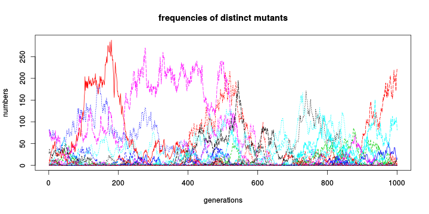

   ```r
   sim_muts <- function (ngens,offspring,muN=mu*N,mu,N,max.muts=muN*100,z0=0) {
       z <- matrix(0L,nrow=max.muts,ncol=ngens)
       z[,1] <- z0
       for (k in 2:ngens) {
           z[,k] <- offspring(z[,k-1])
           new.muts <- sample(which(z[,k]==0), rpois(1,muN)) # errors if max.muts isn't big enough
           z[new.muts,k] <- 1
       }
       return(z)
   }
   s <- 0.001
   # get it started
   history <- sim_muts(ngens=1000,offspring=function(z){rpois(length(z),lambda=(1-s)*z)},muN=1,max.muts=200)
   history <- sim_muts(ngens=1000,offspring=function(z){rpois(length(z),lambda=(1-s)*z)},muN=1,max.muts=200,z0=history[,1000])
   matplot(t(history),type='l',main="frequencies of distinct mutants",xlab="generations",ylab="numbers")
   ```

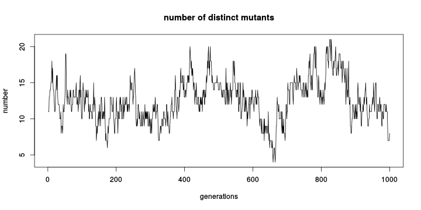

   ```r
   plot(colSums(history>0),type='l',main="number of distinct mutants",xlab="generations",ylab="number")
   ```

2. From the simulation, estimate the distribution of the number of distinct mutations present in the population and the frequency of the most common mutation.

   **Solution:**

   Run it for longer this time:

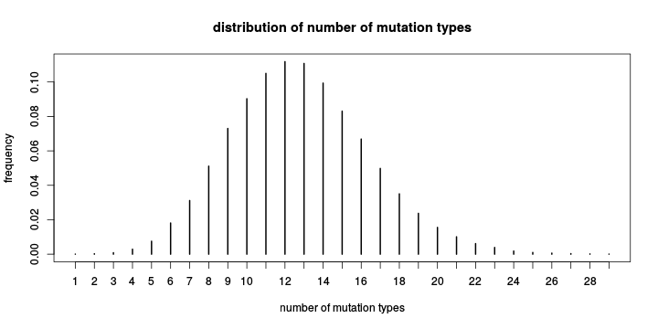

   ```r
   pois.hist <- sim_muts(ngens=100000,offspring=function(z){rpois(length(z),lambda=(1-s)*z)},muN=1,max.muts=200,z0=history[,ncol(history)])
   plot( table( colSums(pois.hist>0) )/ncol(pois.hist), ylab="frequency", xlab="number of mutation types", main="distribution of number of mutation types" )
   ```

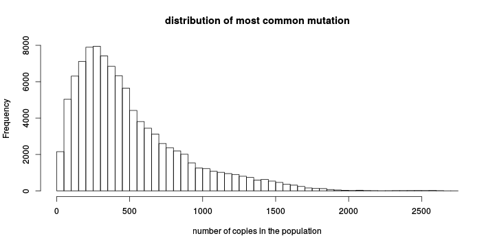

   ```r
   hist( apply(pois.hist,2,max), xlab="number of copies in the population", main="distribution of most common mutation", breaks=50 )
   ```

3. Modify your simulation so that the offspring number is now Binomial$(2,p)$, with $p$ chosen so the mean number of offspring is $1-s$. Estimate the distribution of the number of distinct mutations present, and compare to your answer in (b).

   **Solution:**

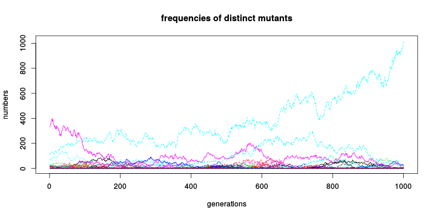

   ```r
   # hm, this one needs longer to reach equilibrium
   binom.fn <- function(z){rbinom(length(z),size=2*z,prob=(1-s)/2)}
   history <- sim_muts(ngens=1000,offspring=binom.fn,muN=1,max.muts=200)
   history <- sim_muts(ngens=1000,offspring=binom.fn,muN=1,max.muts=200,z0=history[,1000])
   matplot(t(history),type='l',main="frequencies of distinct mutants",xlab="generations",ylab="numbers")
   ```

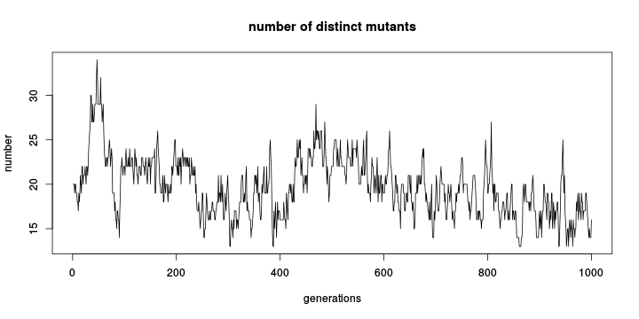

   ```r
   plot(colSums(history>0),type='l',main="number of distinct mutants",xlab="generations",ylab="number")
   ```

   and the results

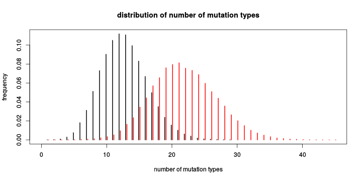

   ```r
   binom.hist <- sim_muts(ngens=100000,offspring=binom.fn,muN=1,max.muts=200,z0=history[,1000])
   binom.counts <- tabulate(colSums(binom.hist>0))/ncol(binom.hist)
   pois.counts <- tabulate(colSums(pois.hist>0))/ncol(pois.hist)
   # plot number of types
   plot(x=seq_along(pois.counts)-0.1, y=pois.counts, type='h', lwd=2, ylab="frequency",
           xlab="number of mutation types", main="distribution of number of mutation types",
           xlim=c(0,max(length(pois.counts),length(binom.counts)))
       )
   points(x=seq_along(binom.counts)+0.1, y=binom.counts, type='h', lwd=2, col='red' )
   ```

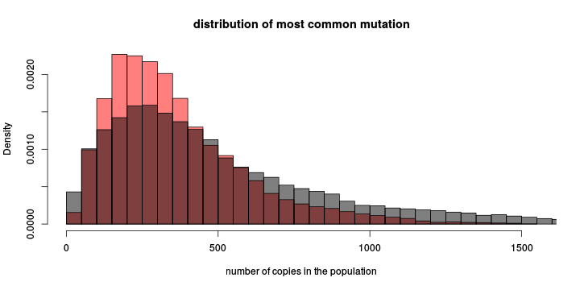

   ```r
   # and size of largest type
   hist( apply(binom.hist,2,max), breaks=50, col=adjustcolor("red",0.5), freq=FALSE,
       xlab="number of copies in the population", main="distribution of most common mutation"  )
   hist( apply(pois.hist,2,max), breaks=50, col=adjustcolor("black",0.5), freq=FALSE, add=TRUE )
   ```

4. In class we showed that the mean number of copies present in the population is $\mu N/s$, regardless of the demographic model. Check this using both simulations above.

   **Solution:**

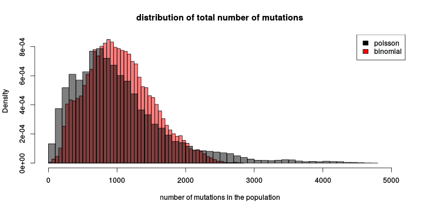

   ```r
   # plot number of types
   hist( colSums(binom.hist), breaks=50, col=adjustcolor("red",0.5), freq=FALSE,
       xlab="number of mutations in the population", main="distribution of total number of mutations",
       xlim=c(0,5000) )
   hist( colSums(pois.hist), breaks=50, col=adjustcolor("black",0.5), freq=FALSE, add=TRUE )
   legend("topright",fill=c('black','red'),legend=c("poisson","binomial"))
   ```

   Here, $\mu N /s = 1000$. The mean number of mutations for the Poisson demography is 1028.587. and for the Binomial demography, the mean is 1040.41012. This is pretty close, we could get standard errors if we account for autocorrelation.